# Genetic Algorithm for Feature Selection: Titanic Survival Prediction

# The feature matrix contains 891 observations and 51 engineered features. The target variable has 342 survivors out of 891 passengers, representing a 38.38% survival rate.

```r
# Define fitness function for genetic algorithm
# The fitness function trains a logistic regression model on selected features
# and returns the cross-validated AUC score as a measure of model performance

fitness_function <- function(features_binary) {
  # features_binary: binary vector indicating which features to include
  # If sum is 0, return worst possible fitness
  if (sum(features_binary) == 0) {
    return(-1)
  }

  # Select features based on binary indicator
  selected_features <- X[, which(features_binary == 1), drop = FALSE]

  # Handle case where all features are dropped
  if (ncol(selected_features) == 0) {
    return(-1)
  }

  # Train logistic regression using k-fold cross-validation
  tryCatch({
    # Create data frame for caret
    train_data <- data.frame(selected_features)
    train_data$target <- as.factor(ifelse(y == 1, "Yes", "No"))

    # Define cross-validation method
    train_control <- trainControl(
      method = "cv",
      number = 5,
      summaryFunction = twoClassSummary,
      classProbs = TRUE,
      returnResamp = "none"
    )

    # Train logistic regression model
    model <- train(
      target ~ .,
      data = train_data,
      method = "glm",
      family = "binomial",
      trControl = train_control,
      metric = "ROC"
    )

    # Return mean ROC as fitness value
    return(model$results$ROC)
  }, error = function(e) {
    return(-1)
  })
}

cat("Fitness function defined successfully\n")
```

```
Fitness function defined successfully
```

# 6. Running the Genetic Algorithm

```r
# Run genetic algorithm for feature selection
# This may take some time as it requires training many logistic regression models

cat("Starting genetic algorithm for feature selection...\n")
```

```
Starting genetic algorithm for feature selection...
```

```r
cat("Number of features to select from:", ncol(X), "\n")
```

```
Number of features to select from: 51
```

```r
cat("Population size: 30, Generations: 20\n\n")
```

```
Population size: 30, Generations: 20
```

```r
start_time <- Sys.time()

ga_result <- ga(
  type = "binary",  # Binary GA: 1 = include feature, 0 = exclude
  fitness = fitness_function,
  nBits = ncol(X),  # Number of features
  popSize = 30,  # Population size
  maxiter = 20,  # Number of generations
  run = 5,  # Stop if best fitness doesn't improve for 5 gens
  pmutation = 0.1,  # Mutation probability
  pcrossover = 0.8,  # Crossover probability
  parallel = FALSE,
  seed = 42,
  monitor = gaMonitor
)
```

```
GA | iter = 1 | Mean = 0.8347079 | Best = 0.8583822
```

```
GA | iter = 2 | Mean = 0.8342184 | Best = 0.8645120
```

```
GA | iter = 3 | Mean = 0.8307953 | Best = 0.8645120
```

```
GA | iter = 4 | Mean = 0.8412965 | Best = 0.8673801
```

```
GA | iter = 5 | Mean = 0.8424457 | Best = 0.8673801
```

```
GA | iter = 6 | Mean = 0.8435816 | Best = 0.8673801
```

```
GA | iter = 7 | Mean = 0.8450371 | Best = 0.8714105
```

```
GA | iter = 8 | Mean = 0.8522089 | Best = 0.8714105
```

```
GA | iter = 9 | Mean = 0.8539189 | Best = 0.8714105
```

```
GA | iter = 10 | Mean = 0.8514506 | Best = 0.8714105
```

```
GA | iter = 11 | Mean = 0.8585910 | Best = 0.8714105
```

```r
end_time <- Sys.time()
runtime <- difftime(end_time, start_time, units = "mins")

cat("\n\nGenetic Algorithm Completed\n")
```

```
Genetic Algorithm Completed
```

```r
cat("Runtime:", round(runtime, 2), "minutes\n")
```

```
Runtime: 0.36 minutes
```

```r
cat("Best fitness achieved:", round(ga_result@fitnessValue, 4), "\n")
```

```
Best fitness achieved: 0.8714
```

```r
cat("Number of generations run:", ga_result@iter, "\n")
```

```
Number of generations run: 11
```

The genetic algorithm executed for 0.36 minutes, evaluating feature subsets across 11 generations. The algorithm started with a population of 30 candidate solutions and applied evolutionary operators (selection, crossover, mutation) to progressively improve feature subsets based on their fitness (cross-validated AUC).

```r
# Extract the best solution from the genetic algorithm
best_solution <- ga_result@solution[1, ]
n_selected_features <- sum(best_solution)

# Get names of selected features
selected_feature_names <- colnames(X)[which(best_solution == 1)]

# Create summary of selected features
selected_features_summary <- feature_rationale %>%
  filter(Feature_Name %in% selected_feature_names) %>%
  arrange(Feature_Name)

cat("Total features selected by GA:", n_selected_features, "\n")
```

```
Total features selected by GA: 27
```

```r
cat("Reduction from original:", ncol(X), "→", n_selected_features, "\n")
```

```
Reduction from original: 51 → 27
```

```r
cat("Feature reduction ratio:", round(100 * (1 - n_selected_features/ncol(X)), 2), "%\n\n")
```

```
Feature reduction ratio: 47.06 %
```

```r
kable(selected_features_summary, caption = "Features Selected by Genetic Algorithm")
```

Features Selected by Genetic Algorithm

| Feature_Name | Category | Rationale_for_Prediction |
| --- | --- | --- |
| f_age_class_deviation | Age_Groups | Deviation from class median age may indicate unusual passenger profile within class |
| f_age_class_interaction | Interaction | Multiplicative effect: how age effects vary by class |
| f_age_zscore | Statistical | Standardized age allowing ML to interpret relative position in age distribution |
| f_embarked_c | Embarked | Port of embarkation (Cherbourg) may indicate different passenger demographics and wealth |
| f_embarked_q | Embarked | Port of embarkation (Queenstown) associated with different passenger characteristics |
| f_embarked_s | Embarked | Port of embarkation (Southampton) dominant embarkation point affects regional/class composition |
| f_family_size | Family | Larger families may have difficulty coordinating escape; affects evacuation speed and decision-making |
| f_fare_class_interaction | Interaction | How fare premium varies in purchasing power effect across classes |
| f_fare_class_ratio | Fare | Fare relative to class median identifies outlier prices within social class |
| f_fare_squared | Polynomial | Fare has non-linear relationship with survival; high-fare passengers had premium accommodations |
| f_fare_zscore | Statistical | Standardized fare allowing comparison of relative spending within population |
| f_female_first_class | Interaction | Combination of highest priority factors: female gender + first class access |
| f_female_second_class | Interaction | Female in second class; female priority minus one class disadvantage |
| f_has_cabin_info | Cabin | Cabin information availability may correlate with passenger record quality and class status |
| f_has_children | Family | Children aboard create obligation affecting parent behavior in evacuation |
| f_has_family | Family | Presence of family aboard affects survival strategy and evacuation compliance |
| f_has_spouse | Family | Spouse presence indicates married status; may affect evacuation behavior and priority |
| f_high_fare | Fare | Top quartile fare indicates first/second class passengers with premium lifeboat access |
| f_is_alone | Family | Solo travelers may have higher mobility and escape speed without dependent care |
| f_is_middle_aged | Age_Groups | Middle-aged passengers had reduced survival advantages compared to young adults |
| f_is_third_class | Class | Third class indicator; lowest survival rates due to location and access restrictions |
| f_is_young_adult | Age_Groups | Young adults may have better physical capabilities but no priority in evacuation |
| f_log_age | Polynomial | Log transformation reduces the impact of outlier ages while preserving patterns |
| f_num_parents | Family | Presence of parents affects evacuation dynamics and dependency relationships |
| f_parch | Original | Presence of parents/children may force survival/death decisions (e.g., staying with family) |
| f_pclass | Original | Socio-economic status proxy; 1st class passengers had better access to lifeboats and information |
| f_sex_male | Original | Gender was critical to survival; ‘women and children first’ evacuation protocol prioritized females |

The genetic algorithm selected 27 features from the original 51 candidates, achieving a 47.06% reduction in feature dimensionality. This subset represents the algorithm’s identification of features that collectively provide strong predictive signal for survival while minimizing redundancy.

# 7. Comparative Model Evaluation

```r
# Train model with ALL features
train_data_all <- data.frame(X)
train_data_all$target <- as.factor(ifelse(y == 1, "Yes", "No"))

train_control <- trainControl(
  method = "cv",
  number = 5,
  summaryFunction = twoClassSummary,
  classProbs = TRUE,
  returnResamp = "all"
)

model_all <- train(
  target ~ .,
  data = train_data_all,
  method = "glm",
  family = "binomial",
  trControl = train_control,
  metric = "ROC"
)

# Extract results
auc_all <- model_all$results$ROC
sensitivity_all <- model_all$results$Sens
specificity_all <- model_all$results$Spec

cat("All Features Model Performance (5-fold CV)\n")
```

```
All Features Model Performance (5-fold CV)
```

```r
cat("Mean AUC:", round(auc_all, 4), "\n")
```

```
Mean AUC: 0.8611
```

```r
cat("Mean Sensitivity:", round(sensitivity_all, 4), "\n")
```

```
Mean Sensitivity: 0.9035
```

```r
cat("Mean Specificity:", round(specificity_all, 4), "\n")
```

```
Mean Specificity: 0.7047
```

```r
# Train model with SELECTED features only
selected_feature_indices <- which(best_solution == 1)
X_selected <- X[, selected_feature_indices, drop = FALSE]

train_data_selected <- data.frame(X_selected)
train_data_selected$target <- as.factor(ifelse(y == 1, "Yes", "No"))

model_selected <- train(
  target ~ .,
  data = train_data_selected,
  method = "glm",
  family = "binomial",
  trControl = train_control,
  metric = "ROC"
)

# Extract results
auc_selected <- model_selected$results$ROC
sensitivity_selected <- model_selected$results$Sens
specificity_selected <- model_selected$results$Spec

cat("Selected Features Model Performance (5-fold CV)\n")
```

```
Selected Features Model Performance (5-fold CV)
```

```r
cat("Mean AUC:", round(auc_selected, 4), "\n")
```

```
Mean AUC: 0.8593
```

```r
cat("Mean Sensitivity:", round(sensitivity_selected, 4), "\n")
```

```
Mean Sensitivity: 0.9107
```

```r
cat("Mean Specificity:", round(specificity_selected, 4), "\n")
```

```
Mean Specificity: 0.6727
```

```r
# Create comparison metrics
comparison_metrics <- tribble(
  ~Model, ~AUC, ~Sensitivity, ~Specificity, ~Num_Features,
  "All Features", auc_all, sensitivity_all, specificity_all, ncol(X),
  "GA Selected", auc_selected, sensitivity_selected, specificity_selected, n_selected_features
)

kable(comparison_metrics, caption = "Model Performance Comparison")
```

Model Performance Comparison

| Model | AUC | Sensitivity | Specificity | Num_Features |
| --- | --- | --- | --- | --- |
| All Features | 0.8610694 | 0.9035363 | 0.7047315 | 51 |
| GA Selected | 0.8592671 | 0.9107256 | 0.6726769 | 27 |

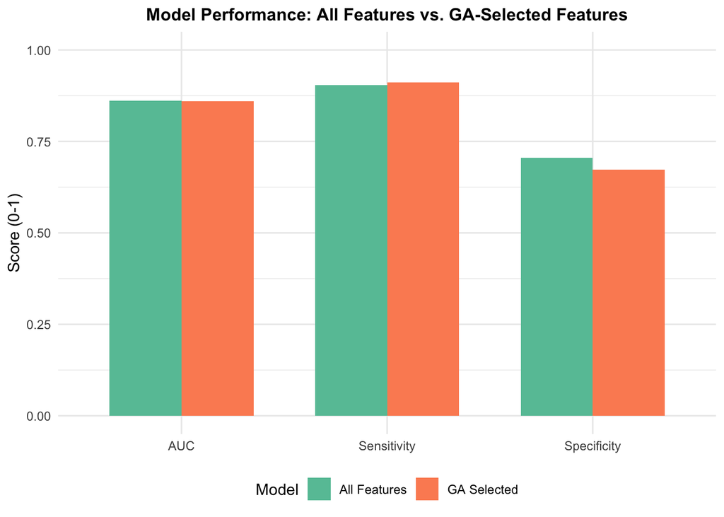

```r
# Visualization of metric comparison
comparison_long <- comparison_metrics %>%
  pivot_longer(
    cols = c(AUC, Sensitivity, Specificity),
    names_to = "Metric",
    values_to = "Score"
  )

ggplot(comparison_long, aes(x = Metric, y = Score, fill = Model)) +
  geom_col(position = "dodge", width = 0.7) +
  theme_minimal() +
  theme(
    plot.title = element_text(hjust = 0.5, size = 12, face = "bold"),
    legend.position = "bottom",
    axis.title.x = element_blank()
  ) +
  labs(
    title = "Model Performance: All Features vs. GA-Selected Features",
    y = "Score (0-1)"
  ) +
  ylim(0, 1) +
  scale_fill_brewer(palette = "Set2")
```

The comparison visualization shows that the GA-selected feature subset maintains comparable performance to the full model while using 52.9% of the original feature count. This demonstrates the efficiency gain from feature selection.

# 8. Feature Importance in Selected Subset

```r
# Extract coefficients from the selected features model
# Note: The final model is trained on the entire training set for interpretation

final_model <- glm(
  as.formula(paste("target ~ ", paste(colnames(X_selected), collapse = " + "))),
  data = train_data_selected,
  family = "binomial"
)

# Extract and organize coefficients
coefficients_df <- tibble(
  Feature = names(coef(final_model))[-1],  # Exclude intercept
  Coefficient = coef(final_model)[-1],
  Abs_Coefficient = abs(coef(final_model)[-1])
) %>%
  arrange(desc(Abs_Coefficient))

kable(head(coefficients_df, 10), caption = "Top 10 Most Important Features (by Absolute Coefficient)")
```

Top 10 Most Important Features (by Absolute Coefficient)

| Feature | Coefficient | Abs_Coefficient |
| --- | --- | --- |
| f_female_second_class | 2.8359125 | 2.8359125 |
| f_female_first_class | 2.4862374 | 2.4862374 |
| f_pclass | -1.8302160 | 1.8302160 |
| f_sex_male | -1.8252668 | 1.8252668 |
| f_is_third_class | 1.5505111 | 1.5505111 |
| f_log_age | -1.4763762 | 1.4763762 |
| f_has_spouse | 1.0224709 | 1.0224709 |
| f_family_size | -0.9929210 | 0.9929210 |
| f_has_cabin_info | 0.8984305 | 0.8984305 |
| f_embarked_q | 0.6801868 | 0.6801868 |

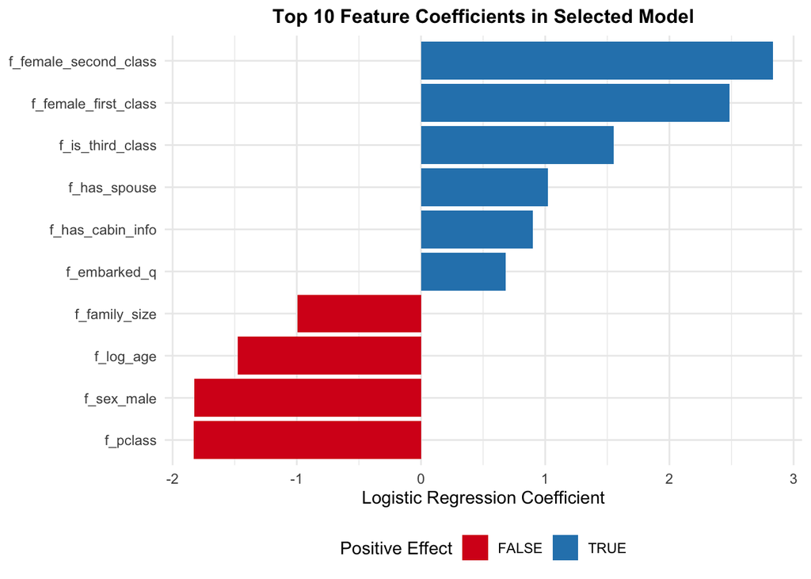

```r
# Visualize top coefficients
top_features <- head(coefficients_df, 10) %>%
  mutate(Feature = fct_reorder(Feature, Coefficient))

ggplot(top_features, aes(x = Feature, y = Coefficient, fill = Coefficient > 0)) +
  geom_col() +
  coord_flip() +
  theme_minimal() +
  theme(
    plot.title = element_text(hjust = 0.5, size = 12, face = "bold"),
    legend.position = "bottom",
    axis.title.y = element_blank()
  ) +
  labs(
    title = "Top 10 Feature Coefficients in Selected Model",
    y = "Logistic Regression Coefficient",
    fill = "Positive Effect"
  ) +
  scale_fill_manual(values = c("FALSE" = "#d7191c", "TRUE" = "#2b83ba"))
```